# CDem: EDA

Rainer

## imports

```r
library(dplyr)
library(tidyverse)
library(tidymodels)
library(ggplot2)
library(corrplot)

Cleaned_CES_2021_Data <- read_csv("numerical_Cleaned_CES_2021_Data.csv")
```

## how does age correlate to politics

lets investigate some interesting correlations. year of birth seems to be consistently negatively correlated with new consumption, political interest, likelihood to vote, populism etc. lets do some quick visual

news consumption vs general interest in politics, coloured by year of birth

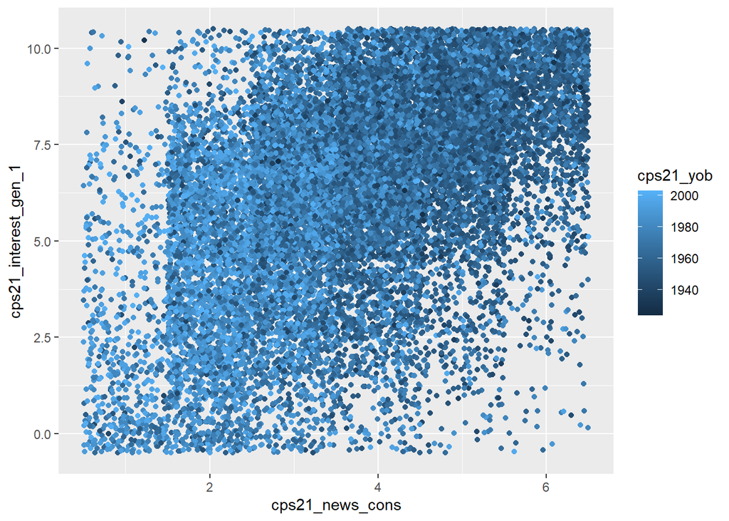

```r
Cleaned_CES_2021_Data |>
  ggplot(aes(x = cps21_news_cons, y = cps21_interest_gen_1, colour = cps21_yob)) +
  geom_jitter(width = 0.5, height = 0.5)
```

news consumption vs general interest in politics, coloured by political partisanship

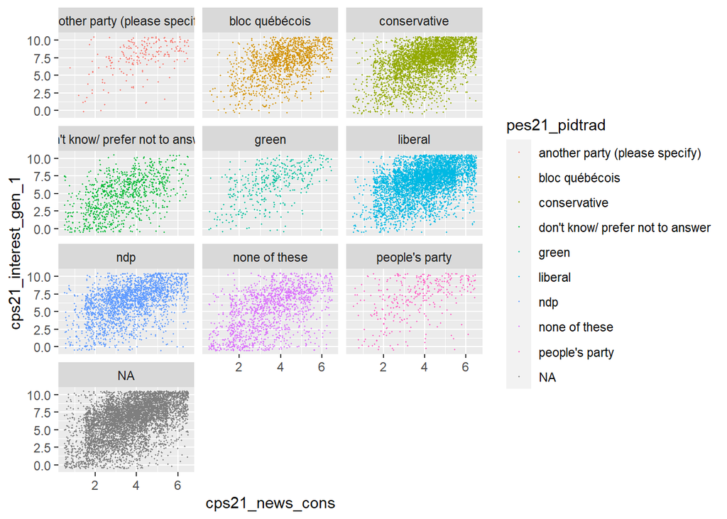

```r
Cleaned_CES_2021_Data |>
  ggplot(aes(x = cps21_news_cons, y = cps21_interest_gen_1, colour = pes21_pidtrad)) +
  geom_jitter(width = 0.5, height = 0.5, size = 0.2) +
  facet_wrap(vars(pes21_pidtrad), nrow = 4)
```

funky. partisonship has nothing to do with political interest/news consumption, even thought younger people have been well documented to be generally more liberal. lets check this

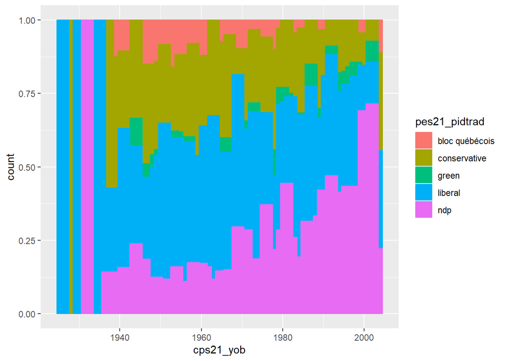

```r
Cleaned_CES_2021_Data |>
  filter(pes21_pidtrad == c("conservative","liberal","ndp","green","bloc québécois"))|>
  ggplot(aes(x = cps21_yob, fill = pes21_pidtrad, colour = pes21_pidtrad)) +
  geom_bar(position = "fill", width = 3)
```

anyways, quick summary: age is correlated to political interest and partisanship. but political interest and partisanship do not interact. age is an *independent* predictor of partisanship.

# question proposal: what are the main predictors of partisanship?

how should we approach this?

- make a lot of visuals and see if anything comes up. this is technically feasible, but a lot of effort. also not very scalable. skip for now
- multi linear regression is not viable. partisanship is a cotegorical variable
- ML model seems to be a good bet to me…